# IODS course project

Jani Haukka

# Introduction to Open Data Science - Course Project

Excluding chapter 4 from HTML page, as index.html can’t be knitted with it. I made no changes to chapter 4 since last week, when it worked…

# About the project

Link to the github page: https://sirtx.github.io/IODS-project/

```r
# This is a so-called "R chunk" where you can write R code.

date()
```

```
## [1] "Mon Dec 13 08:57:14 2021"
```

# Open Data Science course

I heard about this course from PhD School’s mailing list, and other PhD students in our group had taken the course couple years ago, and found it useful. I’m using **R** and **RStudio** regularly during my work, but I’ve used **git/github** very little, and never used **RMarkdown** before, so I hope the course will improve my skills and routines for:

- code documentation
- visualization
- version control

# Chapter 2 - Regression and model validation

```r
date()
```

```
## [1] "Mon Dec 13 08:57:14 2021"
```

*Reading the data frame*

```r
library(ggplot2)
library(GGally)
l2014<-read.table('data/learning_2014_out.csv', header = T, sep = ',', stringsAsFactors = F)
```

Looking at the data structure

```r
str(l2014)
```

```
## 'data.frame':    166 obs. of  7 variables:
##  $ gender  : chr  "F" "M" "F" "M" ...
##  $ age     : int  53 55 49 53 49 38 50 37 37 42 ...
##  $ attitude: num  3.7 3.1 2.5 3.5 3.7 3.8 3.5 2.9 3.8 2.1 ...
##  $ deep    : num  3.58 2.92 3.5 3.5 3.67 ...
##  $ stra    : num  3.38 2.75 3.62 3.12 3.62 ...
##  $ surf    : num  2.58 3.17 2.25 2.25 2.83 ...
##  $ points  : int  25 12 24 10 22 21 21 31 24 26 ...
```

```r
head(l2014)
```

```
##   gender age attitude     deep  stra     surf points
## 1      F  53      3.7 3.583333 3.375 2.583333     25
## 2      M  55      3.1 2.916667 2.750 3.166667     12
## 3      F  49      2.5 3.500000 3.625 2.250000     24
## 4      M  53      3.5 3.500000 3.125 2.250000     10
## 5      M  49      3.7 3.666667 3.625 2.833333     22
## 6      F  38      3.8 4.750000 3.625 2.416667     21
```

The data consists of 7 variables and 166 observations.  
It includes students’ performance metrics in three subject categories: deep learning “deep”, strategic learning “stra”, surface learning “surf” and exam point in “points” and attitude in their own variables. The deep and surf are based on 12 average of 12 questions from each subjects and stra is based on aaverage of 8 strategic questions.

The dataset also contains students’ gender and age in their respective variables.

```r
summary(l2014)
```

```
##     gender               age           attitude          deep
##  Length:166         Min.   :17.00   Min.   :1.400   Min.   :1.583
##  Class :character   1st Qu.:21.00   1st Qu.:2.600   1st Qu.:3.333
##  Mode  :character   Median :22.00   Median :3.200   Median :3.667
##                     Mean   :25.51   Mean   :3.143   Mean   :3.680
##                     3rd Qu.:27.00   3rd Qu.:3.700   3rd Qu.:4.083
##                     Max.   :55.00   Max.   :5.000   Max.   :4.917
##       stra            surf           points
##  Min.   :1.250   Min.   :1.583   Min.   : 7.00
##  1st Qu.:2.625   1st Qu.:2.417   1st Qu.:19.00
##  Median :3.188   Median :2.833   Median :23.00
##  Mean   :3.121   Mean   :2.787   Mean   :22.72
##  3rd Qu.:3.625   3rd Qu.:3.167   3rd Qu.:27.75
##  Max.   :5.000   Max.   :4.333   Max.   :33.00
```

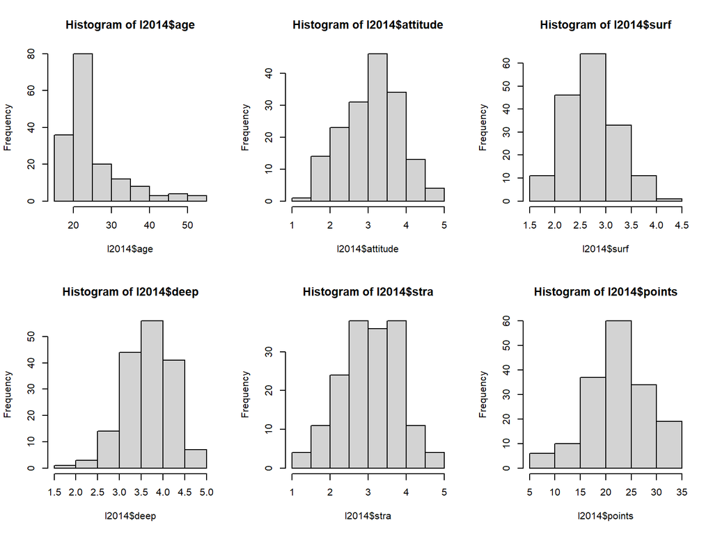

```r
par(mfrow = c(2,3))
hist(l2014$age)
hist(l2014$attitude)
hist(l2014$surf)
hist(l2014$deep)
hist(l2014$stra)
hist(l2014$points)
```

Besides age, the variables are fairly normally distributed, stra variable is also “middle-heavy”

## Exxploring variables and relationships

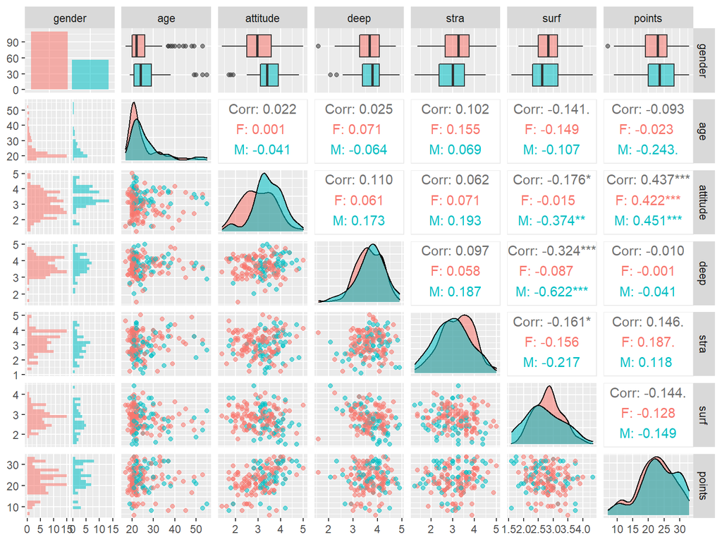

```r
(p <- ggpairs(l2014, mapping = aes(col = gender, alpha = 0.3), lower = list(combo = wrap("facethist", bins = 20))))
```

From the graphical summary we can see that there were significantly more woman than men.All in all the variables were fairly equal in both genders, notably males had slightly higher attitude scroe compared females, whereas females had bit higher surface score compared to males.

Exam points are most highly significantly correlated with attitude and somewhat correlated strategic questions, and negatively correlated with surface questions.

Age did not significantly correlate with exam points and other variables.

## Fitting regression model

```r
# create a regression model with multiple explanatory variables
my_model <- lm(points ~ deep + stra + attitude, data = l2014)

# print out a summary of the model
summary(my_model)
```

```
##
## Call:
## lm(formula = points ~ deep + stra + attitude, data = l2014)
##
## Residuals:
##      Min       1Q   Median       3Q      Max
## -17.5239  -3.4276   0.5474   3.8220  11.5112
##
## Coefficients:
##             Estimate Std. Error t value Pr(>|t|)
## (Intercept)  11.3915     3.4077   3.343  0.00103 **
## deep         -0.7492     0.7507  -0.998  0.31974
## stra          0.9621     0.5367   1.793  0.07489 .
## attitude      3.5254     0.5683   6.203 4.44e-09 ***
## ---
## Signif. codes:  0 '***' 0.001 '**' 0.01 '*' 0.05 '.' 0.1 ' ' 1
##
## Residual standard error: 5.289 on 162 degrees of freedom
## Multiple R-squared:  0.2097, Adjusted R-squared:  0.195
## F-statistic: 14.33 on 3 and 162 DF,  p-value: 2.521e-08
```

Model’s multiple R-squared is 0.2097. This means that about 21% the of variance of points that can be explained by the attitude, stra and deep.

Model’s Residual standard error: 5.289 on 162 degrees of freedom.

We can see that the “stra” and “deep” do not have statistically significant relationship with the points (P-value > 0.05). The only significant explanatory variable “attitude” has a positive relationship with points (Estimate: 3.5254), and it’s highly significant with P-value of 4.44e-09. The model’s non-zero crossing of X-axis is also highly significant.

Therefore we drop these 2 variables and linear model with points as target variable and only attitude as explanatory variable

```r
# fit a linear model with points as target variable and attitude as explanatory variable
my_model2 <- lm(points ~ attitude, data = l2014)

# print out a summary of the model
summary(my_model2)
```

```
##
## Call:
## lm(formula = points ~ attitude, data = l2014)
##
## Residuals:
##      Min       1Q   Median       3Q      Max
## -16.9763  -3.2119   0.4339   4.1534  10.6645
##
## Coefficients:
##             Estimate Std. Error t value Pr(>|t|)
## (Intercept)  11.6372     1.8303   6.358 1.95e-09 ***
## attitude      3.5255     0.5674   6.214 4.12e-09 ***
## ---
## Signif. codes:  0 '***' 0.001 '**' 0.01 '*' 0.05 '.' 0.1 ' ' 1
##
## Residual standard error: 5.32 on 164 degrees of freedom
## Multiple R-squared:  0.1906, Adjusted R-squared:  0.1856
## F-statistic: 38.61 on 1 and 164 DF,  p-value: 4.119e-09
```

Here we see that the attitude still has significant relationship with points (P-value = 4.12e-09), when it’s the only explanatory variable. Model’s multiple R-squared remained at 0.1906, indicating that dropping “deep” and “stra” only affected model’s performance little.

## Model validation

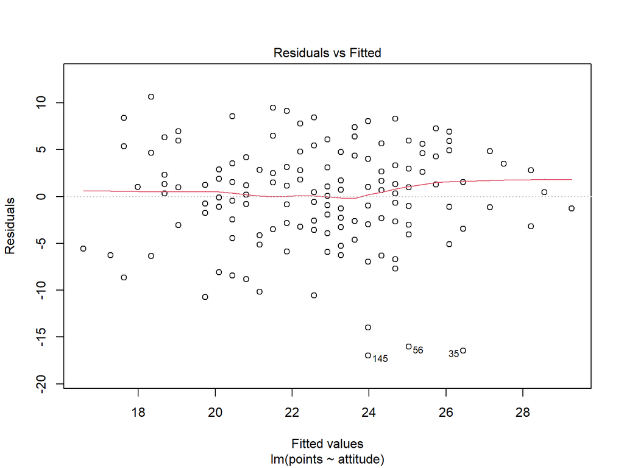

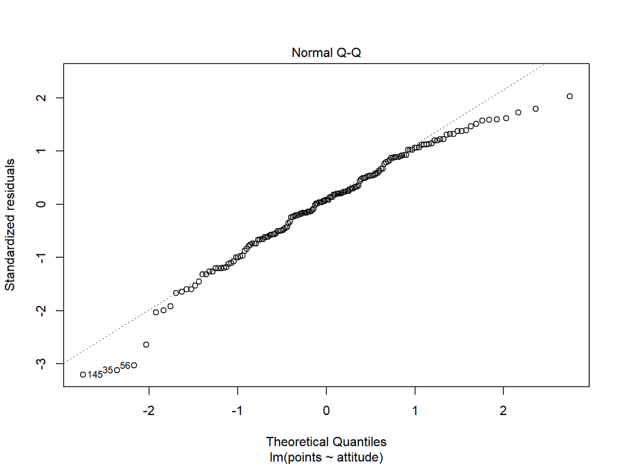

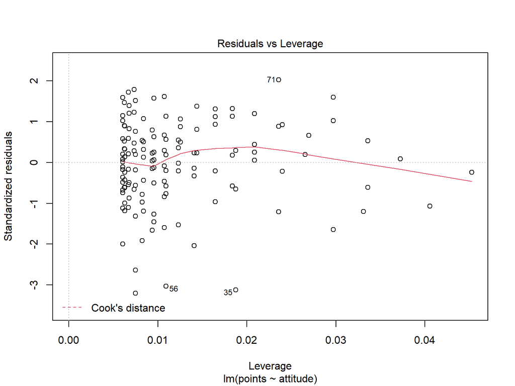

```r
# draw diagnostic plots using the plot() function. Choose the plots 1, 2 and 5
plot(my_model2, which = c(1,2,5))
```

Residuals vs. fitted values plot shows that modeol’s explanatory variables don’t seem to have too much effect on residuals.

The QQ-plot shows that the normality assumption of fairly well, as most of the residuals remain near the normality line.

At Residuals vs leverage plot we can see that some points have bit high leevrage (x-axis values) but even these aren’t outside Cook’s distance, so model shouldn’t be affected too much by them.

# Chapter 3 - Logistic Regression

```r
date()
```

```
## [1] "Mon Dec 13 08:57:22 2021"
```

```r
library(ggplot2)
library(GGally)
library(dplyr)
alc<-read.table("https://github.com/rsund/IODS-project/raw/master/data/alc.csv",header = T, sep = ",")
# alc<-read.table("data/alc.csv",header = T, sep = ";")
colnames(alc)
```

```
##  [1] "school"     "sex"        "age"        "address"    "famsize"
##  [6] "Pstatus"    "Medu"       "Fedu"       "Mjob"       "Fjob"
## [11] "reason"     "guardian"   "traveltime" "studytime"  "schoolsup"
## [16] "famsup"     "activities" "nursery"    "higher"     "internet"
## [21] "romantic"   "famrel"     "freetime"   "goout"      "Dalc"
## [26] "Walc"       "health"     "n"          "id.p"       "id.m"
## [31] "failures"   "paid"       "absences"   "G1"         "G2"
## [36] "G3"         "failures.p" "paid.p"     "absences.p" "G1.p"
## [41] "G2.p"       "G3.p"       "failures.m" "paid.m"     "absences.m"
## [46] "G1.m"       "G2.m"       "G3.m"       "alc_use"    "high_use"
## [51] "cid"
```

This data is the result of data wrangling exercise (though I loaded the orignal online source to be sure I have 100% start point). It includes students’ math (G1-3.m) and Portuguese (G1-3.p) final class grades, together with alcohol use, gender and social factors, such as class absences, family support, etc. Full info of variable meanings can be found here: https://archive.ics.uci.edu/ml/datasets/Student+Performance

The 4 variables of interest for me to be studied in relation to alcohol use were: gender of subjects (sex) number of past class failures (failures) 0-3, 4 if more quality of family relationships (famrel) from 1 - very bad to 5 - excellent number of school absences (absences) from 0 to 93

My initial prediction is that males use on average more alcohol than females, students who have high number of past class failures and absences use more alcohol, and those who have better family relationships use less alcohol on average.

making subset of data.frame, that includes only the studied variables:

```r
alc_study<-subset(alc, select = c(high_use, alc_use, sex, failures, famrel, absences))

alc %>% group_by(sex) %>% summarise(count = n())
```

```
## # A tibble: 2 x 2
##   sex   count
##   <chr> <int>
## 1 F       195
## 2 M       175
```

```r
alc %>% group_by(absences) %>% summarise(count = n())
```

```
## # A tibble: 26 x 2
##    absences count
##       <int> <int>
##  1        0    63
##  2        1    50
##  3        2    56
##  4        3    38
##  5        4    35
##  6        5    22
##  7        6    21
##  8        7    12
##  9        8    20
## 10        9    11
## # ... with 16 more rows
```

```r
alc %>% group_by(failures) %>% summarise(count = n())
```

```
## # A tibble: 4 x 2
##   failures count
##      <int> <int>
## 1        0   325
## 2        1    24
## 3        2    17
## 4        3     4
```

```r
alc %>% group_by(famrel) %>% summarise(count = n())
```

```
## # A tibble: 5 x 2
##   famrel count
##    <int> <int>
## 1      1     8
## 2      2    18
## 3      3    64
## 4      4   180
## 5      5   100
```

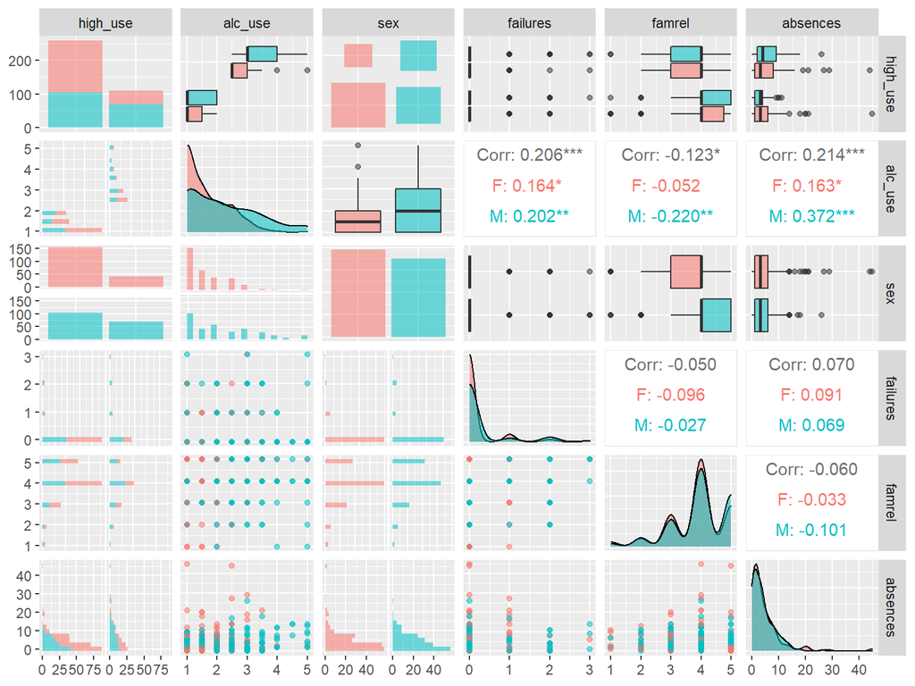

```r
(p <- ggpairs(alc_study, mapping = aes(col = sex, alpha = 0.3), lower = list(combo = wrap("facethist", bins = 20))))
```

Based on the summaries and graphs the initial predictions were fairly correct: males drink more alcohol on average, absences and failures have positive correlation with alcohol use whereas the famrel has negative correlation.

## Logistic regression model

Here I use logistic regression model to study the factors’ relationships with high alcohol usage

```r
# find the model with glm()
m <- glm(high_use ~ failures + absences + sex + famrel, data = alc, family = "binomial")

# print out a summary of the model
summary(m)
```

```
##
## Call:
## glm(formula = high_use ~ failures + absences + sex + famrel,
##     family = "binomial", data = alc)
##
## Deviance Residuals:
##     Min       1Q   Median       3Q      Max
## -2.0786  -0.8216  -0.5746   0.9760   2.1820
##
## Coefficients:
##             Estimate Std. Error z value Pr(>|z|)
## (Intercept) -0.79406    0.54281  -1.463  0.14350
## failures     0.57328    0.20531   2.792  0.00523 **
## absences     0.08941    0.02274   3.932 8.43e-05 ***
## sexM         1.04800    0.25091   4.177 2.96e-05 ***
## famrel      -0.29791    0.13044  -2.284  0.02238 *
## ---
## Signif. codes:  0 '***' 0.001 '**' 0.01 '*' 0.05 '.' 0.1 ' ' 1
##
## (Dispersion parameter for binomial family taken to be 1)
##
##     Null deviance: 452.04  on 369  degrees of freedom
## Residual deviance: 401.77  on 365  degrees of freedom
## AIC: 411.77
##
## Number of Fisher Scoring iterations: 4
```

```r
# print out the coefficients of the model
coef(m)
```

```
## (Intercept)    failures    absences        sexM      famrel
## -0.79406437  0.57327802  0.08940969  1.04800182 -0.29791173
```

```r
 coef(m) %>% exp
```

```
## (Intercept)    failures    absences        sexM      famrel
##   0.4520039   1.7740730   1.0935286   2.8519467   0.7423669
```

failures (OR=1.77), absences (OR=1.09) and male sex (OR=2.85) have odds ratio above 1 for high alcohol use, which means they increase the risk for high alcohol use, i.e. makes are at 185% more risk for high alcohol usage than females. THe famrel (good family relations, OR=0.74) in turn has odds ratio below 1, which means good students with family relation have are reduced risk of high alcohol use.

All four variables have at least nominally significant P-values (P<0.05).

The odds ratios support the predictions and correlations I made before.

## Model performance

Here I test model performance with crosstabs and loss function:

```r
# predict() the probability of high_use
probabilities <- predict(m, type = "response")

# add the predicted probabilities to 'alc'
alc <- mutate(alc, probability = probabilities)

# use the probabilities to make a prediction of high_use
alc <- mutate(alc, prediction = (probabilities > 0.5))

# tabulate the target variable versus the predictions
table(high_use = alc$high_use, prediction = alc$prediction)
```

```
##         prediction
## high_use FALSE TRUE
##    FALSE   244   15
##    TRUE     77   34
```

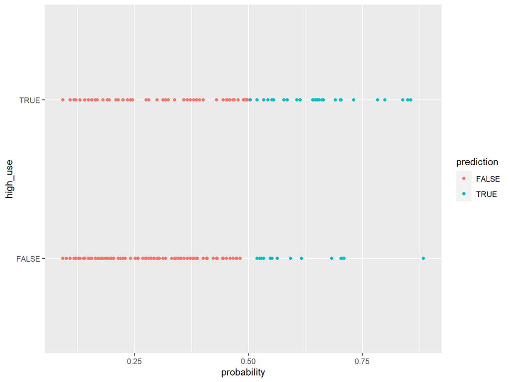

```r
p1 <- ggplot(alc, aes(x = probability, y = high_use, col = prediction))
p1 + geom_point()
```

```r
# define a loss function (mean prediction error)
loss_func <- function(class, prob) {
  n_wrong <- abs(class - prob) > 0.5
  mean(n_wrong)
}

# call loss_func to compute the average number of wrong predictions in the (training) data
loss_func(class = alc$high_use, prob = 0)
```

```
## [1] 0.3
```

## 10-fold cross-validation

Here I perform 10-fold cross-validation for my model.

```r
# K-fold cross-validation
library(boot)

cv <- cv.glm(data = alc, cost = loss_func, glmfit = m, K = 10)

# average number of wrong predictions in the cross validation
cv$delta[1]
```

```
## [1] 0.2513514
```

My model had 0.25 error, which is slightly better than DataCamp model’s error of 0.26. My model is very similar to DataCamp’s, and it only includes 1 extra variable (famrel), which seems to only slightly improve the model performance.

# Chapter 5 - Dimension reduction

```r
date()
```

```
## [1] "Mon Dec 13 08:57:32 2021"
```

## Data lookup

First loading the dataset and looking variable characteristics with summaries and histograms

```r
library(tidyr)
library(dplyr)
library(GGally)
library(corrplot)
human<-read.table("http://s3.amazonaws.com/assets.datacamp.com/production/course_2218/datasets/human2.txt", header = T, sep = ",")

str(human)
```

```
## 'data.frame':    155 obs. of  8 variables:
##  $ Edu2.FM  : num  1.007 0.997 0.983 0.989 0.969 ...
##  $ Labo.FM  : num  0.891 0.819 0.825 0.884 0.829 ...
##  $ Edu.Exp  : num  17.5 20.2 15.8 18.7 17.9 16.5 18.6 16.5 15.9 19.2 ...
##  $ Life.Exp : num  81.6 82.4 83 80.2 81.6 80.9 80.9 79.1 82 81.8 ...
##  $ GNI      : int  64992 42261 56431 44025 45435 43919 39568 52947 42155 32689 ...
##  $ Mat.Mor  : int  4 6 6 5 6 7 9 28 11 8 ...
##  $ Ado.Birth: num  7.8 12.1 1.9 5.1 6.2 3.8 8.2 31 14.5 25.3 ...
##  $ Parli.F  : num  39.6 30.5 28.5 38 36.9 36.9 19.9 19.4 28.2 31.4 ...
```

```r
head(human)
```

```
##               Edu2.FM   Labo.FM Edu.Exp Life.Exp   GNI Mat.Mor Ado.Birth
## Norway      1.0072389 0.8908297    17.5     81.6 64992       4       7.8
## Australia   0.9968288 0.8189415    20.2     82.4 42261       6      12.1
## Switzerland 0.9834369 0.8251001    15.8     83.0 56431       6       1.9
## Denmark     0.9886128 0.8840361    18.7     80.2 44025       5       5.1
## Netherlands 0.9690608 0.8286119    17.9     81.6 45435       6       6.2
## Germany     0.9927835 0.8072289    16.5     80.9 43919       7       3.8
##             Parli.F
## Norway         39.6
## Australia      30.5
## Switzerland    28.5
## Denmark        38.0
## Netherlands    36.9
## Germany        36.9
```

```r
summary(human)
```

```
##     Edu2.FM          Labo.FM          Edu.Exp         Life.Exp
##  Min.   :0.1717   Min.   :0.1857   Min.   : 5.40   Min.   :49.00
##  1st Qu.:0.7264   1st Qu.:0.5984   1st Qu.:11.25   1st Qu.:66.30
##  Median :0.9375   Median :0.7535   Median :13.50   Median :74.20
##  Mean   :0.8529   Mean   :0.7074   Mean   :13.18   Mean   :71.65
##  3rd Qu.:0.9968   3rd Qu.:0.8535   3rd Qu.:15.20   3rd Qu.:77.25
##  Max.   :1.4967   Max.   :1.0380   Max.   :20.20   Max.   :83.50
##       GNI            Mat.Mor         Ado.Birth         Parli.F
##  Min.   :   581   Min.   :   1.0   Min.   :  0.60   Min.   : 0.00
##  1st Qu.:  4198   1st Qu.:  11.5   1st Qu.: 12.65   1st Qu.:12.40
##  Median : 12040   Median :  49.0   Median : 33.60   Median :19.30
##  Mean   : 17628   Mean   : 149.1   Mean   : 47.16   Mean   :20.91
##  3rd Qu.: 24512   3rd Qu.: 190.0   3rd Qu.: 71.95   3rd Qu.:27.95
##  Max.   :123124   Max.   :1100.0   Max.   :204.80   Max.   :57.50
```

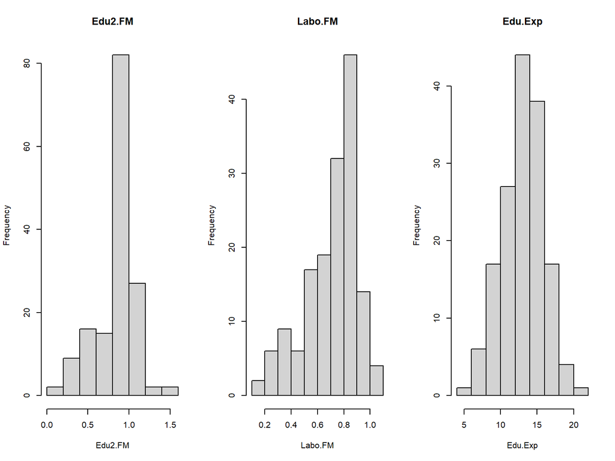

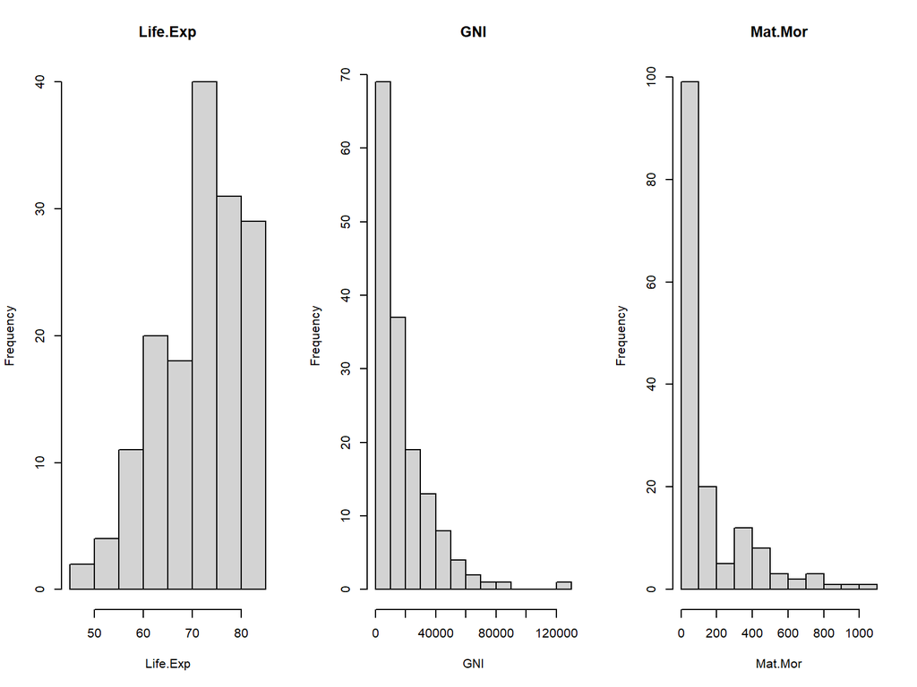

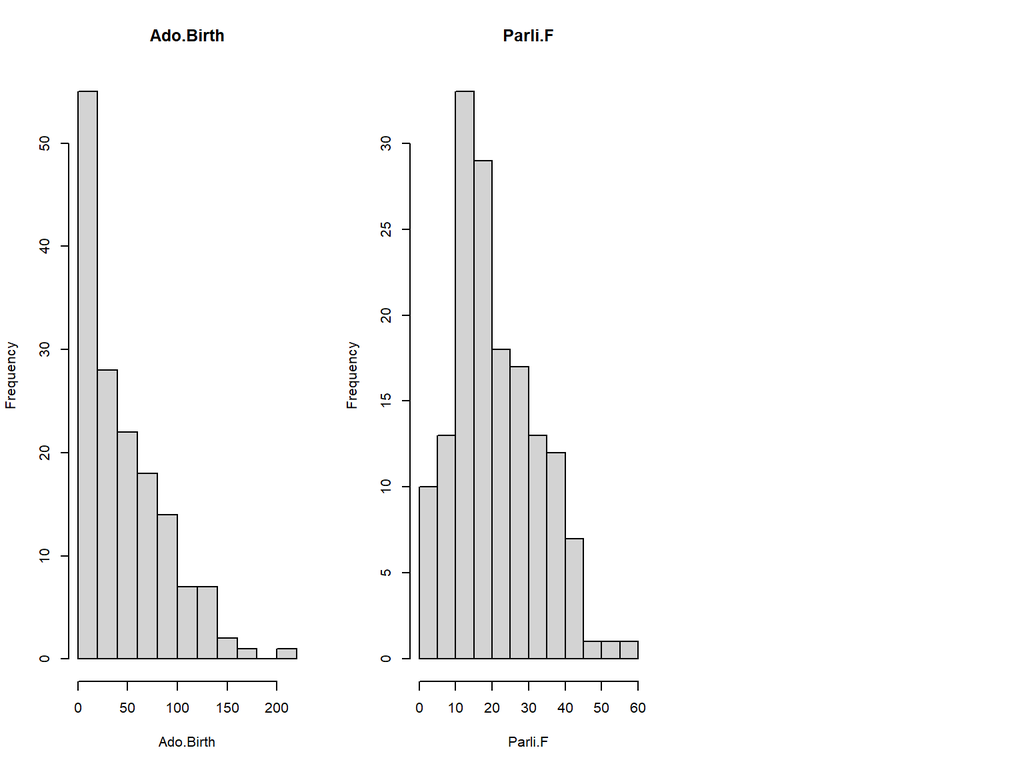

```r
### Looking at histograms for variables
for (col in seq(from=1, ncol(human), by=3)) {
  par(mfrow = c(1,3))
  hist(human[,col], xlab = colnames(human)[col], main = colnames(human)[col] )
  hist(human[,col+1], xlab = colnames(human)[col+1], main = colnames(human)[col+1])
  if (col+2<= ncol(human))
    hist(human[,col+2], xlab = colnames(human)[col+2], main = colnames(human)[col+2])
}
```

The dataset is jointed from 2 datasets, human development “hd” and Gender inequality “gii”, which info can be found here http://hdr.undp.org/en/content/human-development-index-hdi. The joined dataset contains 8 variables and 155 oservations, with countries as rownames. Here are short descriptions for variables:

Edu2.FM: 2nd female eductaion / 2nd Male education ratio Labo.FM: 2nd female labor force participation / 2nd Male force participation ratio Edu.Exp: Expected years of schooling Life.Exp: Life expectancy (years) GNI: Gross National Income Mat.Mor: Eternal mortality rate Ado.Birth: Adolescent birth rate Parli.F: % of females in parliament

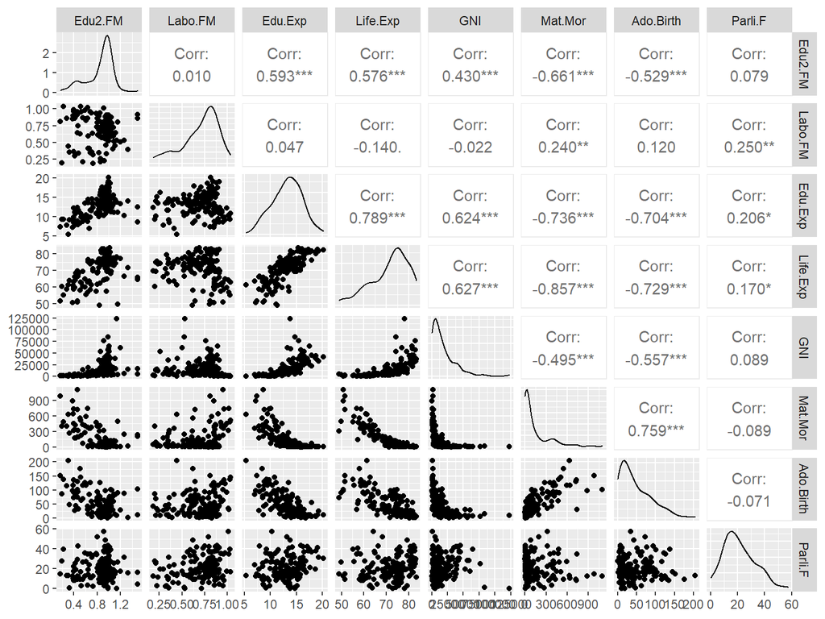

```r
ggpairs(human)
```

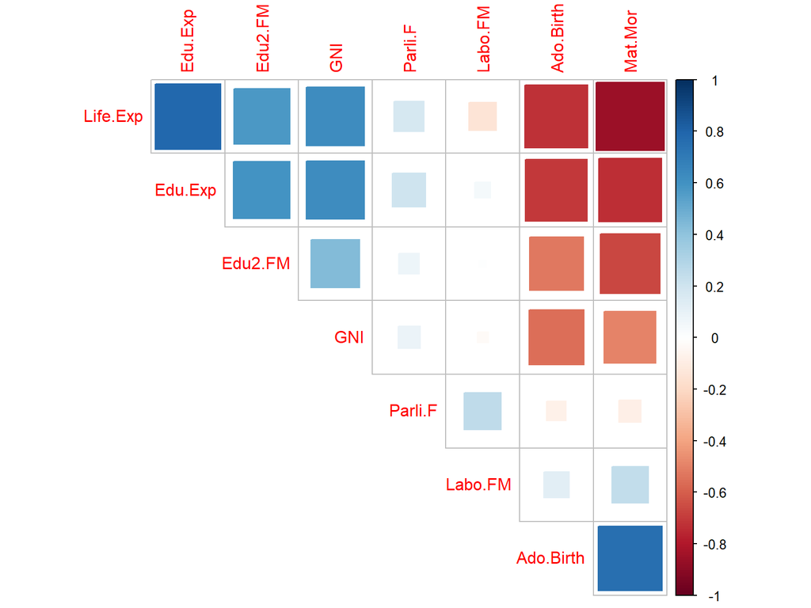

```r
corrplot(cor(human),  method = 'square', order = 'FPC',  type = 'upper', diag = FALSE)
```

From the ggpairs and correlation plot we can see that there were several significant positive and negative correltions between variables. Strong statistically significant positive correlations were observed between: Adolescent births and maternal mortality, Life expectancy and 1) education expectancy, 2) higher female 2nd education ratio and 3) Gross National Income Education expectancy and 1) higher female 2nd education ratio 2) Gross National Income Higher female 2nd education ratio and Gross National Income

Strong statistically significant negative correlations were observed between: Maternal mortality and 1) life expectancy, 2) education expectancy, 3) higher female 2nd education ratio, 4) Gross National Income Adolescent births and all 4 variables that were negatively correlated with maternal mortality

## PCA on non-standardized data

Here, I’m performing Principal Component Analysis (PCA) with R’s prcomp() default Singular Value Decomposition (SVD). THE PCA is an unsupervised dimension reduction method, in which data is first transformed to a new space with equal or less number of dimensions (PCs), and the 1st principal component captures the maximum amount of variance from the features in the original data, the 2nd principal component is orthogonal to the first and it captures the maximum amount of variability left, and so on.

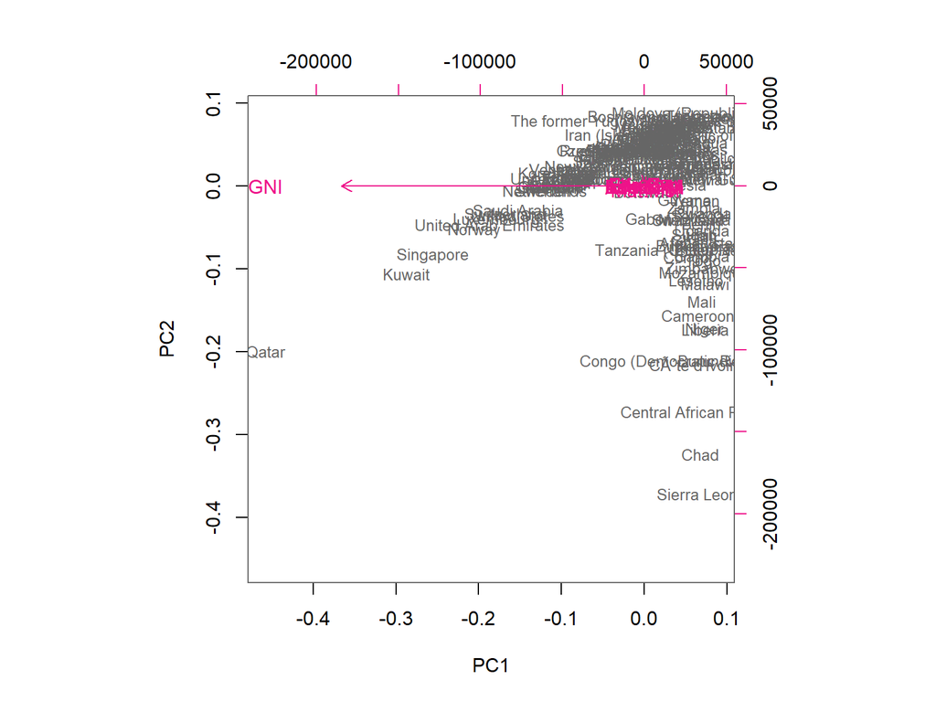

```r
# perform principal component analysis (with the SVD method)
pca_human <- prcomp(human)

# draw a biplot of the principal component representation and the original variables
biplot(pca_human, choices = 1:2, cex = c(0.8, 1), col = c("grey40", "deeppink2"))
```

Here PCA is visualized with biplot. Variation within the variables is shown with arrow length and correlation between the variables is shown with angle between arrows. As the data isn’t normalized, most of the PC1/PC2 values are packed to upper right corner, with large outliers elsewhere.

## Standardizing the data, performing PCA and explaining PCs

Here I standardize the data with scale() function (mean of 0), and do another pca-biplot with variability explained by PCs shown on axis labels.

```r
# standardize the variables
human_std <- scale(human)

# print out summaries of the standardized variables
summary(human_std)
```

```
##     Edu2.FM           Labo.FM           Edu.Exp           Life.Exp
##  Min.   :-2.8189   Min.   :-2.6247   Min.   :-2.7378   Min.   :-2.7188
##  1st Qu.:-0.5233   1st Qu.:-0.5484   1st Qu.:-0.6782   1st Qu.:-0.6425
##  Median : 0.3503   Median : 0.2316   Median : 0.1140   Median : 0.3056
##  Mean   : 0.0000   Mean   : 0.0000   Mean   : 0.0000   Mean   : 0.0000
##  3rd Qu.: 0.5958   3rd Qu.: 0.7350   3rd Qu.: 0.7126   3rd Qu.: 0.6717
##  Max.   : 2.6646   Max.   : 1.6632   Max.   : 2.4730   Max.   : 1.4218
##       GNI             Mat.Mor          Ado.Birth          Parli.F
##  Min.   :-0.9193   Min.   :-0.6992   Min.   :-1.1325   Min.   :-1.8203
##  1st Qu.:-0.7243   1st Qu.:-0.6496   1st Qu.:-0.8394   1st Qu.:-0.7409
##  Median :-0.3013   Median :-0.4726   Median :-0.3298   Median :-0.1403
##  Mean   : 0.0000   Mean   : 0.0000   Mean   : 0.0000   Mean   : 0.0000
##  3rd Qu.: 0.3712   3rd Qu.: 0.1932   3rd Qu.: 0.6030   3rd Qu.: 0.6127
##  Max.   : 5.6890   Max.   : 4.4899   Max.   : 3.8344   Max.   : 3.1850
```

```r
# perform principal component analysis (with the SVD method)
pca_human <- prcomp(human_std)

# create and print out a summary of pca_human
s <- summary(pca_human)
s
```

```
## Importance of components:
##                           PC1    PC2     PC3     PC4     PC5     PC6     PC7
## Standard deviation     2.0708 1.1397 0.87505 0.77886 0.66196 0.53631 0.45900
## Proportion of Variance 0.5361 0.1624 0.09571 0.07583 0.05477 0.03595 0.02634
## Cumulative Proportion  0.5361 0.6984 0.79413 0.86996 0.92473 0.96069 0.98702
##                            PC8
## Standard deviation     0.32224
## Proportion of Variance 0.01298
## Cumulative Proportion  1.00000
```

```r
# rounded percentages of variance captured by each PC
pca_pr <- round(100*s$importance[2,], digits = 1)

# print out the percentages of variance
pca_pr
```

```
##  PC1  PC2  PC3  PC4  PC5  PC6  PC7  PC8
## 53.6 16.2  9.6  7.6  5.5  3.6  2.6  1.3
```

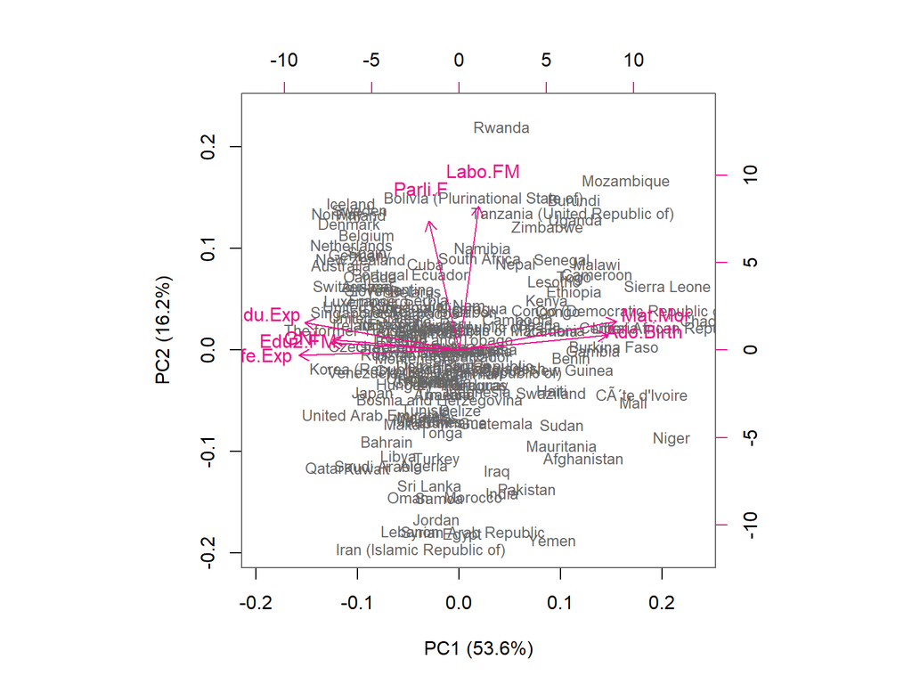

```r
# create object pc_lab to be used as axis labels
pc_lab <- paste0(names(pca_pr), " (", pca_pr, "%)")

# draw a biplot
biplot(pca_human, cex = c(0.8, 1), col = c("grey40", "deeppink2"), xlab = pc_lab[1], ylab = pc_lab[2])
```

The PCs for standardized data look much better, as most of the observations are located at the middle, and it’s much easier to spot the trends shown with the arrows.

The 1st PC expalins 53.6% of the data variablilty, and 2nd PC explains 16.2% of the data. Combined, this is almost 70% of the variability in 8 variables, explained with just 2 (PCs)!

Based on the plot, it looks like that most of variability in variables Mat.Mort and Ado.Birth (positive correlation and PC1 values) and Edu.Exp, Life.Exp, Edu.FM and GNI (positive correlation with each others, negative correlation with Mat.Mort and Ado.Birth and negative PC1 values) are explained in PC1 PC2 explains variablity in Labo.FM and Parli.Fm which have positive but PC2 vaues and positive, but weaker correlation with each other

## Factominer’s tea data

Here we take a look at the “tea” data from Factominer-package.

```r
library(FactoMineR)
data("tea")
str(tea)
```

```
## 'data.frame':    300 obs. of  36 variables:
##  $ breakfast       : Factor w/ 2 levels "breakfast","Not.breakfast": 1 1 2 2 1 2 1 2 1 1 ...
##  $ tea.time        : Factor w/ 2 levels "Not.tea time",..: 1 1 2 1 1 1 2 2 2 1 ...
##  $ evening         : Factor w/ 2 levels "evening","Not.evening": 2 2 1 2 1 2 2 1 2 1 ...
##  $ lunch           : Factor w/ 2 levels "lunch","Not.lunch": 2 2 2 2 2 2 2 2 2 2 ...
##  $ dinner          : Factor w/ 2 levels "dinner","Not.dinner": 2 2 1 1 2 1 2 2 2 2 ...
##  $ always          : Factor w/ 2 levels "always","Not.always": 2 2 2 2 1 2 2 2 2 2 ...
##  $ home            : Factor w/ 2 levels "home","Not.home": 1 1 1 1 1 1 1 1 1 1 ...
##  $ work            : Factor w/ 2 levels "Not.work","work": 1 1 2 1 1 1 1 1 1 1 ...
##  $ tearoom         : Factor w/ 2 levels "Not.tearoom",..: 1 1 1 1 1 1 1 1 1 2 ...
##  $ friends         : Factor w/ 2 levels "friends","Not.friends": 2 2 1 2 2 2 1 2 2 2 ...
##  $ resto           : Factor w/ 2 levels "Not.resto","resto": 1 1 2 1 1 1 1 1 1 1 ...
##  $ pub             : Factor w/ 2 levels "Not.pub","pub": 1 1 1 1 1 1 1 1 1 1 ...
##  $ Tea             : Factor w/ 3 levels "black","Earl Grey",..: 1 1 2 2 2 2 2 1 2 1 ...
##  $ How             : Factor w/ 4 levels "alone","lemon",..: 1 3 1 1 1 1 1 3 3 1 ...
```

[output cut: 22 more lines]

```r
head(tea)
```

```
##       breakfast     tea.time     evening     lunch     dinner     always home
## 1     breakfast Not.tea time Not.evening Not.lunch Not.dinner Not.always home
## 2     breakfast Not.tea time Not.evening Not.lunch Not.dinner Not.always home
## 3 Not.breakfast     tea time     evening Not.lunch     dinner Not.always home
## 4 Not.breakfast Not.tea time Not.evening Not.lunch     dinner Not.always home
## 5     breakfast Not.tea time     evening Not.lunch Not.dinner     always home
## 6 Not.breakfast Not.tea time Not.evening Not.lunch     dinner Not.always home
##       work     tearoom     friends     resto     pub       Tea   How    sugar
## 1 Not.work Not.tearoom Not.friends Not.resto Not.pub     black alone    sugar
## 2 Not.work Not.tearoom Not.friends Not.resto Not.pub     black  milk No.sugar
## 3     work Not.tearoom     friends     resto Not.pub Earl Grey alone No.sugar
## 4 Not.work Not.tearoom Not.friends Not.resto Not.pub Earl Grey alone    sugar
## 5 Not.work Not.tearoom Not.friends Not.resto Not.pub Earl Grey alone No.sugar
## 6 Not.work Not.tearoom Not.friends Not.resto Not.pub Earl Grey alone No.sugar
##       how       where           price age sex          SPC         Sport age_Q
```

[output cut: 27 more lines]

the data contains 36 variables and 300 observations. Next, I select 6 columns for analysis.

```r
q# column names to keep in the dataset
```

[output not shown]

```r
keep_columns <- c("Tea", "How", "how", "sugar", "where", "lunch")

# select the 'keep_columns' to create a new dataset
tea_time <- select(tea, one_of(keep_columns))

# look at the summaries and structure of the data
summary(tea_time)
```

```
##         Tea         How                      how           sugar
##  black    : 74   alone:195   tea bag           :170   No.sugar:155
##  Earl Grey:193   lemon: 33   tea bag+unpackaged: 94   sugar   :145
##  green    : 33   milk : 63   unpackaged        : 36
##                  other:  9
##                   where           lunch
##  chain store         :192   lunch    : 44
##  chain store+tea shop: 78   Not.lunch:256
##  tea shop            : 30
##
```

```r
str(tea_time)
```

```
## 'data.frame':    300 obs. of  6 variables:
##  $ Tea  : Factor w/ 3 levels "black","Earl Grey",..: 1 1 2 2 2 2 2 1 2 1 ...
##  $ How  : Factor w/ 4 levels "alone","lemon",..: 1 3 1 1 1 1 1 3 3 1 ...
##  $ how  : Factor w/ 3 levels "tea bag","tea bag+unpackaged",..: 1 1 1 1 1 1 1 1 2 2 ...
##  $ sugar: Factor w/ 2 levels "No.sugar","sugar": 2 1 1 2 1 1 1 1 1 1 ...
##  $ where: Factor w/ 3 levels "chain store",..: 1 1 1 1 1 1 1 1 2 2 ...
##  $ lunch: Factor w/ 2 levels "lunch","Not.lunch": 2 2 2 2 2 2 2 2 2 2 ...
```

```r
head(tea_time)
```

```
##         Tea   How     how    sugar       where     lunch
## 1     black alone tea bag    sugar chain store Not.lunch
## 2     black  milk tea bag No.sugar chain store Not.lunch
## 3 Earl Grey alone tea bag No.sugar chain store Not.lunch
## 4 Earl Grey alone tea bag    sugar chain store Not.lunch
## 5 Earl Grey alone tea bag No.sugar chain store Not.lunch
## 6 Earl Grey alone tea bag No.sugar chain store Not.lunch
```

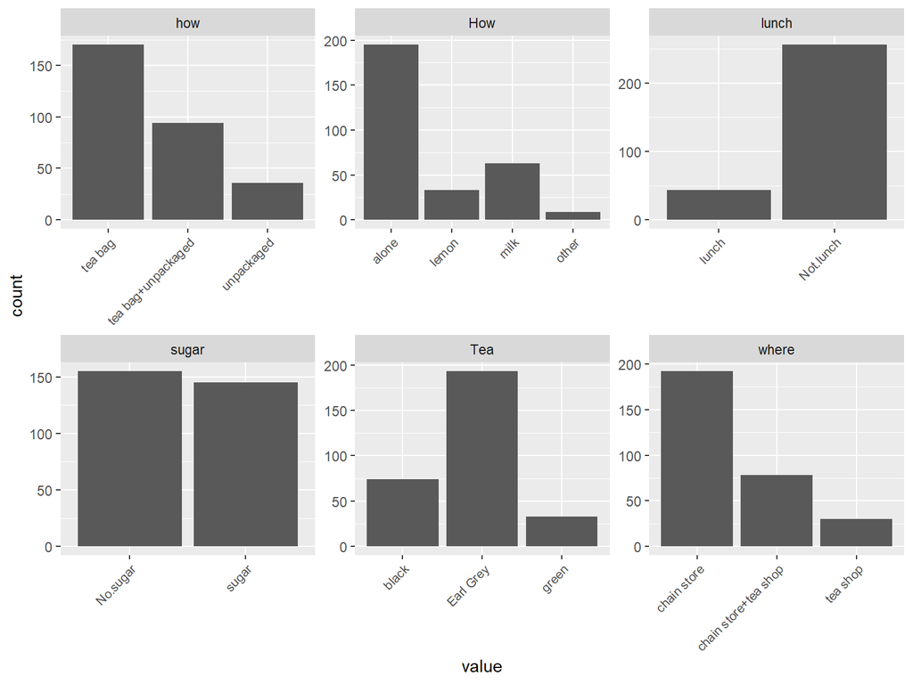

```r
# visualize the dataset
gather(tea_time) %>% ggplot(aes(value)) + facet_wrap("key", scales = "free") + geom_bar() + theme(axis.text.x = element_text(angle = 45, hjust = 1, size = 8))
```

By looking at structure and few top observations, I can see that the selected variables are categorical, with 2-4 categories per variable.

Multiple Correspondence Analysis is another dimensionality reduction method. It’s best suited for qualitative data with categorical variables, but continuous ones can be used as background (supplementary) variables.

```r
# multiple correspondence analysis
mca <- MCA(tea_time, graph = FALSE)

# summary of the model
summary(mca)
```

```
##
## Call:
## MCA(X = tea_time, graph = FALSE)
##
##
## Eigenvalues
##                        Dim.1   Dim.2   Dim.3   Dim.4   Dim.5   Dim.6   Dim.7
## Variance               0.279   0.261   0.219   0.189   0.177   0.156   0.144
## % of var.             15.238  14.232  11.964  10.333   9.667   8.519   7.841
## Cumulative % of var.  15.238  29.471  41.435  51.768  61.434  69.953  77.794
##                        Dim.8   Dim.9  Dim.10  Dim.11
## Variance               0.141   0.117   0.087   0.062
## % of var.              7.705   6.392   4.724   3.385
## Cumulative % of var.  85.500  91.891  96.615 100.000
##
## Individuals (the 10 first)
##                       Dim.1    ctr   cos2    Dim.2    ctr   cos2    Dim.3
## 1                  | -0.298  0.106  0.086 | -0.328  0.137  0.105 | -0.327
## 2                  | -0.237  0.067  0.036 | -0.136  0.024  0.012 | -0.695
## 3                  | -0.369  0.162  0.231 | -0.300  0.115  0.153 | -0.202
## 4                  | -0.530  0.335  0.460 | -0.318  0.129  0.166 |  0.211
## 5                  | -0.369  0.162  0.231 | -0.300  0.115  0.153 | -0.202
## 6                  | -0.369  0.162  0.231 | -0.300  0.115  0.153 | -0.202
## 7                  | -0.369  0.162  0.231 | -0.300  0.115  0.153 | -0.202
## 8                  | -0.237  0.067  0.036 | -0.136  0.024  0.012 | -0.695
## 9                  |  0.143  0.024  0.012 |  0.871  0.969  0.435 | -0.067
## 10                 |  0.476  0.271  0.140 |  0.687  0.604  0.291 | -0.650
##                       ctr   cos2
## 1                   0.163  0.104 |
## 2                   0.735  0.314 |
## 3                   0.062  0.069 |
## 4                   0.068  0.073 |
## 5                   0.062  0.069 |
## 6                   0.062  0.069 |
## 7                   0.062  0.069 |
## 8                   0.735  0.314 |
## 9                   0.007  0.003 |
## 10                  0.643  0.261 |
##
## Categories (the 10 first)
```

[output cut: 16 more lines]

```
## lemon                3.226 |   1.329  14.771   0.218   8.081 |
## milk                 2.422 |   0.013   0.003   0.000   0.116 |
## other                5.534 |  -2.524  14.526   0.197  -7.676 |
## tea bag             -6.941 |  -0.065   0.183   0.006  -1.287 |
## tea bag+unpackaged  11.956 |   0.019   0.009   0.000   0.226 |
## unpackaged          -6.482 |   0.257   0.602   0.009   1.640 |
##
## Categorical variables (eta2)
##                      Dim.1 Dim.2 Dim.3
## Tea                | 0.126 0.108 0.410 |
## How                | 0.076 0.190 0.394 |
## how                | 0.708 0.522 0.010 |
## sugar              | 0.065 0.001 0.336 |
## where              | 0.702 0.681 0.055 |
## lunch              | 0.000 0.064 0.111 |
```

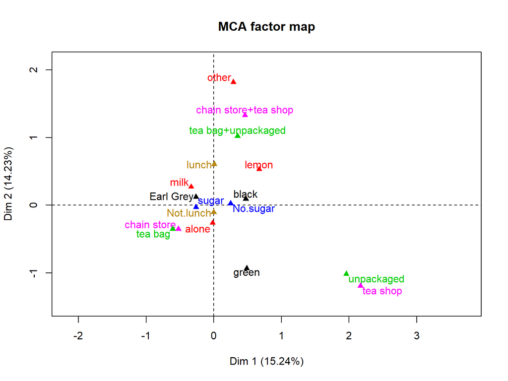

```r
# visualize MCA
plot(mca, invisible=c("ind"), habillage = "quali", graph.type = "classic")
```

Output of MCA summary contains (source: https://tuomonieminen.github.io/Helsinki-Open-Data-Science/#/69):  
- Eigenvalues with the variances and the percentage of variances retained by each dimension  
- The individuals coordinates, the individuals contribution (%) on the dimension and the cos2 (the squared correlations) on the dimensions.  
- Coordinates of the variable categories, the contribution (%), the cos2 (the squared correlations) and v.test value. The v.test follows normal distribution: if the value is below/above ± 1.96, the coordinate is significantly different from zero.  
- Categorical variables, which are squared correlation between each variable and the dimensions. If the value is close to one it indicates a strong link with the variable and dimension.

Summary shows that first 4 dimensions explain about haf of the variance.

From the MCA plot, I see that 29.47% of the variability are explained with Dim 1 and Dim 2. The plot shows correlations for variables, For example it seems that unpackaged tea (how) is almost always bought from tea shop (where) (bottom right), and the “how” and “where” variables appear together elsewhere in the plot, so they seem to have a strong correlation.

# Chapter 6 - Longitudinal data

```r
date()
```

```
## [1] "Mon Dec 13 08:57:42 2021"
```

```r
knitr::opts_chunk$set(fig.width=12, fig.height=8)
```

## RATS

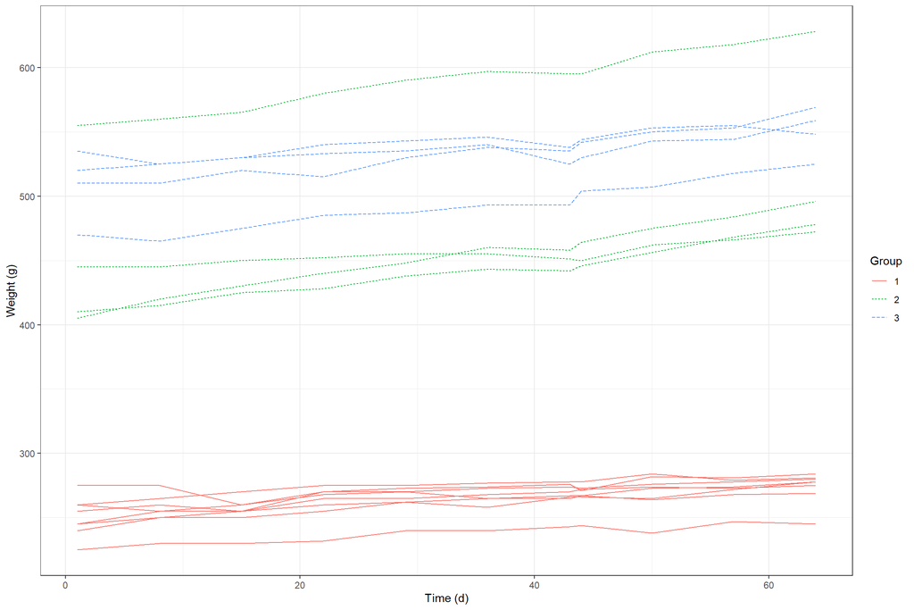

```r
library(ggplot2)
library(dplyr)
library(tidyr)

### Reading the wrangled longidutal RATS data
RATSL<-read.table('data/RATSL.txt', header = T, sep = '\t')

### Reading also the original RATS data for later use
RATS<-read.table('https://raw.githubusercontent.com/KimmoVehkalahti/MABS/master/Examples/data/rats.txt', header = T, sep = '\t')

### Setting ID and Group as factor
RATSL$ID <- factor(RATSL$ID)
RATSL$Group <- factor(RATSL$Group)


### Plotting the RATS dataset
ggplot(RATSL, aes(x = Time, y = Weight, group = ID, col = Group)) +
  geom_line(aes(linetype = Group)) +
  scale_x_continuous(name = "Time (d)") +
  scale_y_continuous(name = "Weight (g)") + theme_bw()
```

### Individual response profiles by group before and after standardization

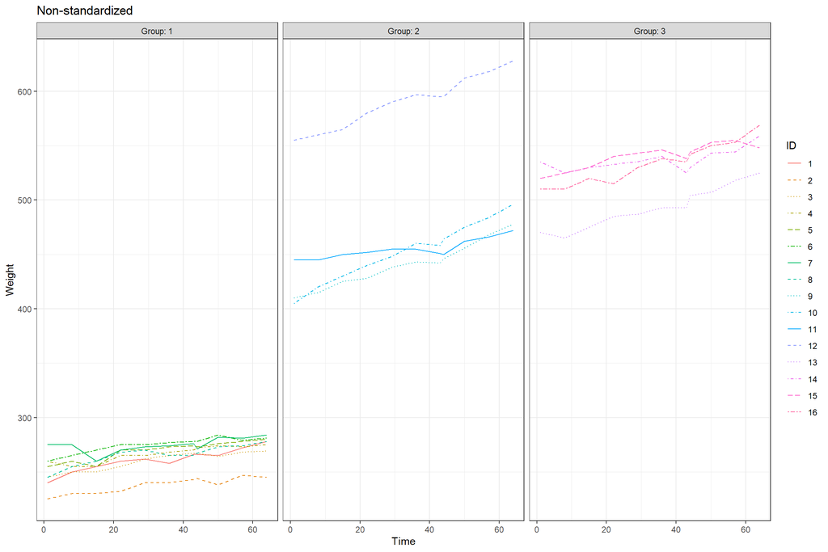

```r
### Plotting individual response profiles by group for RATSL

ggplot(RATSL, aes(x = Time, y = Weight,  col = ID, linetype = ID)) +
  geom_line() +
  scale_linetype_manual(values = rep(1:10, times=11)) +
  facet_grid(. ~ Group, labeller = label_both) +
  theme(legend.position = "none") +
  ggtitle("Non-standardized") +
  scale_y_continuous(limits = c(min(RATSL$Weight), max(RATSL$Weight))) + theme_bw()
```

```r
### Number rats in group
n <- 11
# Summary data with mean
RATSS <- RATSL %>%
  group_by(Time) %>%
  mutate(Weight_std = (Weight - mean(Weight))/sd(Weight)) %>%
  ungroup()


glimpse(RATSS)
```

```
## Rows: 176
## Columns: 6
## $ ID         <fct> 1, 2, 3, 4, 5, 6, 7, 8, 9, 10, 11, 12, 13, 14, 15, 16, 1, 2~
## $ Group      <fct> 1, 1, 1, 1, 1, 1, 1, 1, 2, 2, 2, 2, 3, 3, 3, 3, 1, 1, 1, 1,~
## $ WD         <chr> "WD1", "WD1", "WD1", "WD1", "WD1", "WD1", "WD1", "WD1", "WD~
## $ Weight     <int> 240, 225, 245, 260, 255, 260, 275, 245, 410, 405, 445, 555,~
## $ Time       <int> 1, 1, 1, 1, 1, 1, 1, 1, 1, 1, 1, 1, 1, 1, 1, 1, 8, 8, 8, 8,~
## $ Weight_std <dbl> -1.0011429, -1.1203857, -0.9613953, -0.8421525, -0.8819001,~
```

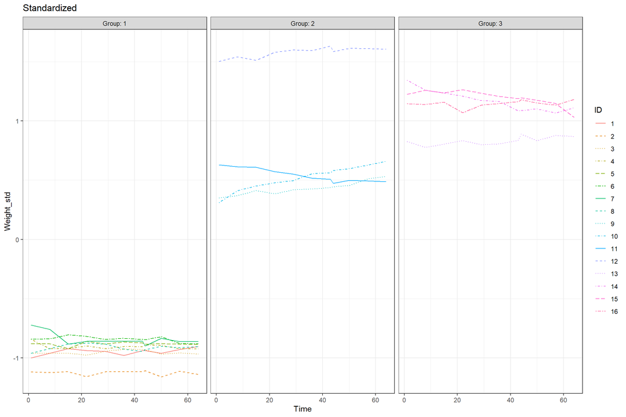

```r
# Plot the mean profiles
ggplot(RATSS, aes(x = Time, y = Weight_std, col = ID, linetype = ID)) +
  geom_line() +
  scale_linetype_manual(values = rep(1:10, times=11)) +
  facet_grid(. ~ Group, labeller = label_both) +
  theme(legend.position = "none") +
  ggtitle("Standardized") +
  scale_y_continuous(limits = c(min(RATSS$Weight_std), max(RATSS$Weight_std))) + theme_bw()
```

Plots show that that removed the trend of increasing weight over time, but the group differences remain.

### Summary measure statistics

Here I try to see the trend of groups, by plottin mean profiles for each treatment group, along within group indication of the variation ( standard error of mean) of the observations at each time point.

```r
### using the n() function from dplyr to get group size
RATSS <- RATSL %>%
  group_by(Group, Time) %>%
  summarise(mean = mean(Weight), se = sd(Weight) /  sqrt(n())) %>%
  ungroup()
### Glimpse at the data
glimpse(RATSS)
```

```
## Rows: 33
## Columns: 4
## $ Group <fct> 1, 1, 1, 1, 1, 1, 1, 1, 1, 1, 1, 2, 2, 2, 2, 2, 2, 2, 2, 2, 2, 2~
## $ Time  <int> 1, 8, 15, 22, 29, 36, 43, 44, 50, 57, 64, 1, 8, 15, 22, 29, 36, ~
## $ mean  <dbl> 250.625, 255.000, 254.375, 261.875, 264.625, 265.000, 267.375, 2~
## $ se    <dbl> 5.381640, 4.629100, 4.057346, 4.808614, 3.909409, 4.166190, 3.87~
```

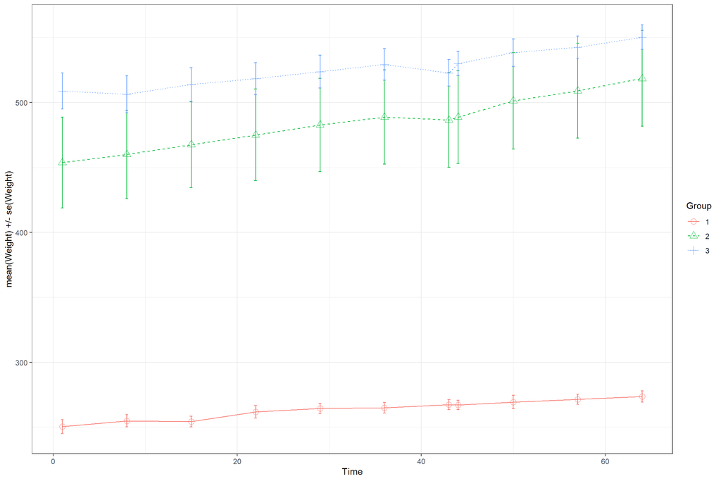

```r
### Line plot for groups
ggplot(RATSS, aes(x = Time, y = mean, linetype = Group, col = Group, shape = Group)) +
  geom_line() +
  scale_linetype_manual(values = c(1,2,3)) +
  geom_point(size=3) +
  scale_shape_manual(values = c(1,2,3)) +
  geom_errorbar(aes(ymin = mean - se, ymax = mean + se, linetype="1"), width=0.3) +
  theme(legend.position = c(0.8,0.8)) +
  scale_y_continuous(name = "mean(Weight) +/- se(Weight)") + theme_bw()
```

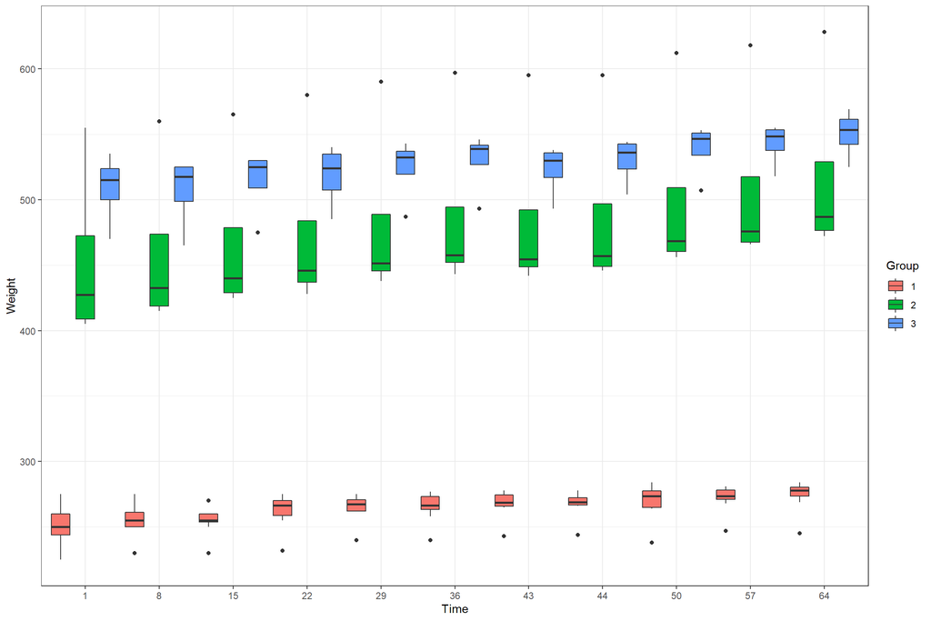

```r
### Box plot for groups
ggplot(RATSL, aes(x = factor(Time), y = Weight, fill = Group)) +
  geom_boxplot(position = position_dodge(width = 1)) +
  scale_x_discrete(name = "Time") + theme_bw()
```

Here I observe again that weight is much heavier on groups 2 and 3 compared to 1. Weight also increases more on 2 and 3 over time, and variability is higher.

### Outliers

Here I check whether there are significant outliers in the dataset

```r
RATSL8S <- RATSL %>%
  filter(Time >= 1) %>%
  group_by(Group, ID) %>%
  summarise( mean=mean(Weight) ) %>%
  ungroup()
```

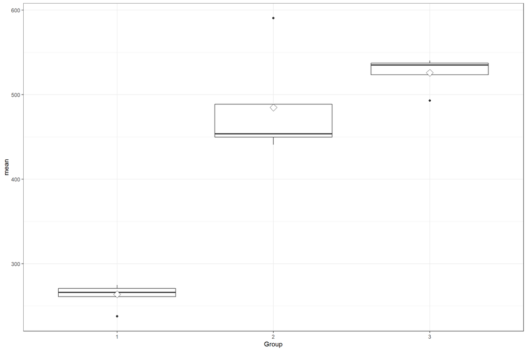

```r
ggplot(RATSL8S, aes(x = Group, y = mean)) +
  geom_boxplot() + stat_summary(fun = "mean", geom = "point", shape=23, size=4, fill = "white") + theme_bw()
```

I can see that there’s a quite significant outlier at group 2, Outliers at 1 and 3 doesn’t seem that large deviations. Let’s remove group 2’s outlier and plot again:

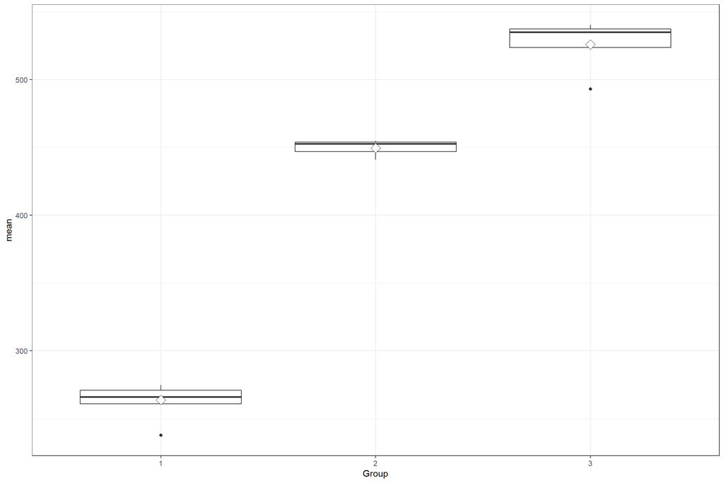

```r
### Remove the outlier from group 2:
RATSL8S1 <- RATSL8S %>%
  filter(mean < 550)


ggplot(RATSL8S1, aes(x = Group, y = mean)) +
  geom_boxplot() + stat_summary(fun = "mean", geom = "point", shape=23, size=4, fill = "white") + theme_bw()
```

No outliers at group 2 anymore!

### ANOVA

Here, I perform ANOVA to observe if graphically observed differences between groups are also statistically significant, by setting Group 1 as baseline.

```r
### Adding baseline values to the summary data
RATSL8S2 <- RATSL8S %>%
  mutate(baseline = RATS$WD1)

### Fitting ANCOVA model
fit <- lm(mean ~ baseline + Group, data = RATSL8S2)

### Summary
summary(fit)
```

```
##
## Call:
## lm(formula = mean ~ baseline + Group, data = RATSL8S2)
##
## Residuals:
##     Min      1Q  Median      3Q     Max
## -21.732  -3.812   1.991   6.889  13.455
##
## Coefficients:
##             Estimate Std. Error t value Pr(>|t|)
## (Intercept) 30.14886   19.88779   1.516   0.1554
## baseline     0.93194    0.07793  11.959 5.02e-08 ***
## Group2      31.68866   17.11189   1.852   0.0888 .
## Group3      21.52296   21.13931   1.018   0.3287
## ---
## Signif. codes:  0 '***' 0.001 '**' 0.01 '*' 0.05 '.' 0.1 ' ' 1
##
## Residual standard error: 10.62 on 12 degrees of freedom
## Multiple R-squared:  0.9947, Adjusted R-squared:  0.9933
## F-statistic: 747.8 on 3 and 12 DF,  p-value: 6.636e-14
```

```r
### Anova
anova(fit)
```

```
## Analysis of Variance Table
##
## Response: mean
##           Df Sum Sq Mean Sq   F value    Pr(>F)
## baseline   1 252125  252125 2237.0655 5.217e-15 ***
## Group      2    726     363    3.2219   0.07586 .
## Residuals 12   1352     113
## ---
## Signif. codes:  0 '***' 0.001 '**' 0.01 '*' 0.05 '.' 0.1 ' ' 1
```

## BPRS

In BPRS dataset “40 male subjects were randomly assigned to one of two treatment groups and each subject was rated on the brief psychiatric rating scale (BPRS) measured before treatment began (week 0) and then at weekly intervals for eight weeks. The BPRS assesses the level of 18 symptom constructs such as hostility, suspiciousness, hallucinations and grandiosity; each of these is rated from one (not present) to seven (extremely severe). The scale is used to evaluate patients suspected of having schizophrenia.” Page 5: https://mooc.helsinki.fi/pluginfile.php/192850/course/section/7335/MABS4IODS-Part6.pdf

```r
### BPRS
library("lme4")
library(gridExtra)
```

```r
library(grid)

### Reading the longidutal BPRS data, which was created in the Wrangling exercise
BPRSL<- read.table('data/BPRSL.txt', header = T, sep = '\t')

### Reading also original BPRS data for some plot
BPRS<-read.table('https://raw.githubusercontent.com/KimmoVehkalahti/MABS/master/Examples/data/BPRS.txt', header = T, sep = ' ')


### Assigning treatment and subject as factors
BPRSL$treatment <- factor(BPRSL$treatment)
BPRSL$subject <- factor(BPRSL$subject)

### Creating unique id variable for individuals as per suggestion on forum
# BPRS$id <- seq.int(nrow(BPRS))

glimpse(BPRSL)
```

```
## Rows: 360
## Columns: 6
## $ treatment <fct> 1, 1, 1, 1, 1, 1, 1, 1, 1, 1, 1, 1, 1, 1, 1, 1, 1, 1, 1, 1, ~
## $ subject   <fct> 1, 2, 3, 4, 5, 6, 7, 8, 9, 10, 11, 12, 13, 14, 15, 16, 17, 1~
## $ id        <int> 1, 2, 3, 4, 5, 6, 7, 8, 9, 10, 11, 12, 13, 14, 15, 16, 17, 1~
## $ weeks     <chr> "week0", "week0", "week0", "week0", "week0", "week0", "week0~
## $ bprs      <int> 42, 58, 54, 55, 72, 48, 71, 30, 41, 57, 30, 55, 36, 38, 66, ~
## $ week      <int> 0, 0, 0, 0, 0, 0, 0, 0, 0, 0, 0, 0, 0, 0, 0, 0, 0, 0, 0, 0, ~
```

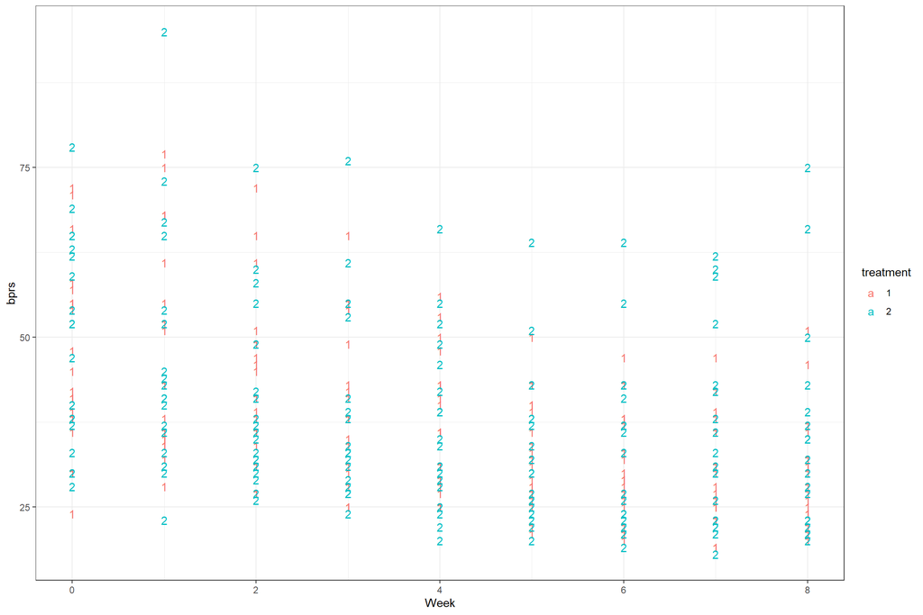

```r
ggplot(BPRSL, aes(x = week, y = bprs, group = subject, col = treatment)) +
  geom_text(aes(label = treatment)) +
  scale_x_continuous(name = "Week") +
  scale_y_continuous(name = "bprs") + theme_bw()
```

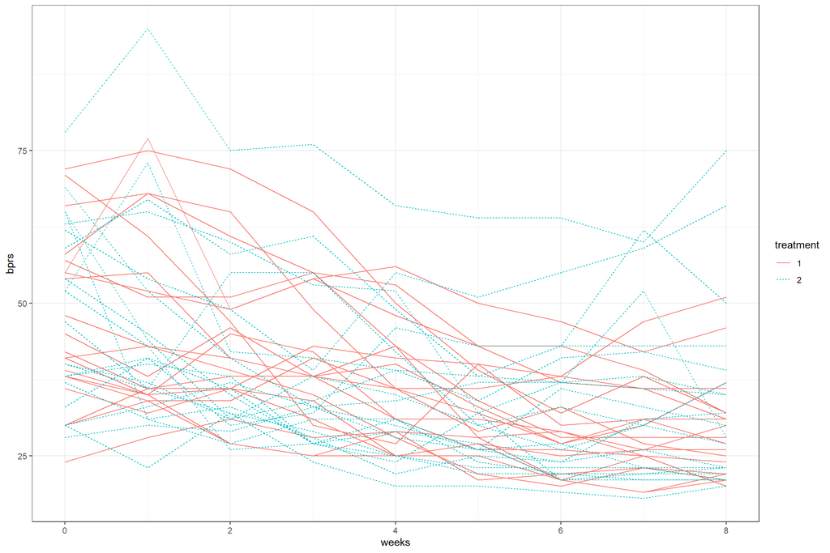

```r
ggplot(BPRSL, aes(x = week, y = bprs, group = id, col = treatment)) +
  geom_line(aes(linetype = treatment)) +
  scale_x_continuous(name = "weeks") +
  scale_y_continuous(name = "bprs") +
  theme(legend.position = "top") + theme_bw()
```

Here I plot the BPRS change along time, red solid line individuals belong to treatment group 1, blue dotted line to group 2. From these 2 plots, It looks like bprs score slightly goes down as time goes by, and that group 2 has slightly higher score, but the variance is also larger within group 2.

### Trends from data: pairwise measurements

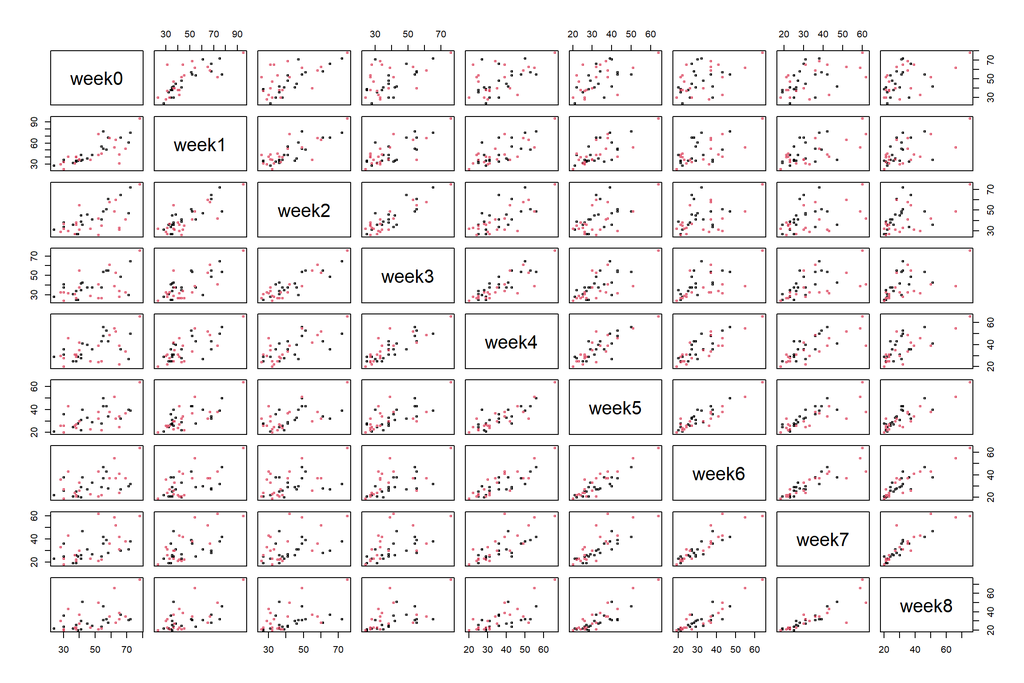

```r
pairs(BPRS[, 3:11], cex = 0.5, col = BPRS$treatment)
```

Pairwise measurements suggest that bprs scores aren’t independent between measurements

### The Linear model

Here I implement a basic linear model for the data.

```r
### create a regression model BPRSL_reg
BPRSL_reg <- lm(bprs ~ week + treatment, data = BPRSL)

### print out a summary of the model
summary(BPRSL_reg)
```

```
##
## Call:
## lm(formula = bprs ~ week + treatment, data = BPRSL)
##
## Residuals:
##     Min      1Q  Median      3Q     Max
## -22.454  -8.965  -3.196   7.002  50.244
##
## Coefficients:
##             Estimate Std. Error t value Pr(>|t|)
## (Intercept)  46.4539     1.3670  33.982   <2e-16 ***
## week         -2.2704     0.2524  -8.995   <2e-16 ***
## treatment2    0.5722     1.3034   0.439    0.661
## ---
## Signif. codes:  0 '***' 0.001 '**' 0.01 '*' 0.05 '.' 0.1 ' ' 1
##
## Residual standard error: 12.37 on 357 degrees of freedom
## Multiple R-squared:  0.1851, Adjusted R-squared:  0.1806
## F-statistic: 40.55 on 2 and 357 DF,  p-value: < 2.2e-16
```

Altogether, the model explains 18,06% of bprs variance. Summary shows that measure time “week” is statistically significant (P<2e-16) in explaining bprs, whereas treatment is not. However, linear model isn’t (P=0.661). However, it should be noted that model assumes repeated measurements aren’t related, which isn’t true here.

### Fitting Random Intercept Model to to BPRS dataset, treatment and week are explanatory variables

```r
### Create a random intercept model
BPRSL_ref <- lmer(bprs ~ week + treatment + (1 | id), data = BPRSL, REML = FALSE)

### Print the summary of the model
summary(BPRSL_ref)
```

```
## Linear mixed model fit by maximum likelihood  ['lmerMod']
## Formula: bprs ~ week + treatment + (1 | id)
##    Data: BPRSL
##
##      AIC      BIC   logLik deviance df.resid
##   2582.9   2602.3  -1286.5   2572.9      355
##
## Scaled residuals:
##      Min       1Q   Median       3Q      Max
## -2.27506 -0.59909 -0.06104  0.44226  3.15835
##
## Random effects:
##  Groups   Name        Variance Std.Dev.
##  id       (Intercept) 97.39    9.869
##  Residual             54.23    7.364
## Number of obs: 360, groups:  id, 40
##
## Fixed effects:
##             Estimate Std. Error t value
## (Intercept)  46.4539     2.3521  19.750
## week         -2.2704     0.1503 -15.104
## treatment2    0.5722     3.2159   0.178
##
## Correlation of Fixed Effects:
##            (Intr) week
## week       -0.256
## treatment2 -0.684  0.000
```

### Random Intercept and Random Slope Model

Fitting a random intercept and random slope model allows the linear regression fits for each individual to differ in intercept but also in slope. This way it is possible to account for the individual differences in the bprs profiles, but also the effect of time.

```r
### ref1
BPRS_ref1 <- lmer(bprs ~ week + treatment + (week | id), data = BPRSL, REML = FALSE)


### print a summary of the model
summary(BPRS_ref1)
```

```
## Linear mixed model fit by maximum likelihood  ['lmerMod']
## Formula: bprs ~ week + treatment + (week | id)
##    Data: BPRSL
##
##      AIC      BIC   logLik deviance df.resid
##   2523.2   2550.4  -1254.6   2509.2      353
##
## Scaled residuals:
##     Min      1Q  Median      3Q     Max
## -2.4655 -0.5150 -0.0920  0.4347  3.7353
##
## Random effects:
##  Groups   Name        Variance Std.Dev. Corr
##  id       (Intercept) 167.827  12.955
##           week          2.331   1.527   -0.67
##  Residual              36.747   6.062
## Number of obs: 360, groups:  id, 40
##
## Fixed effects:
##             Estimate Std. Error t value
## (Intercept)  45.9830     2.6470  17.372
## week         -2.2704     0.2713  -8.370
## treatment2    1.5139     3.1392   0.482
##
## Correlation of Fixed Effects:
##            (Intr) week
## week       -0.545
## treatment2 -0.593  0.000
```

### Random Intercept and Random Slope Model with interaction

Here I am making Random Intercept and Random Slope Model with interaction, which treatment × time interaction.

```r
# create a random intercept and random slope model
BPRS_ref2 <- lmer(bprs ~ week * treatment + (week | id), data = BPRSL, REML = FALSE)

# print a summary of the model
summary(BPRS_ref2)
```

```
## Linear mixed model fit by maximum likelihood  ['lmerMod']
## Formula: bprs ~ week * treatment + (week | id)
##    Data: BPRSL
##
##      AIC      BIC   logLik deviance df.resid
##   2523.5   2554.5  -1253.7   2507.5      352
##
## Scaled residuals:
##     Min      1Q  Median      3Q     Max
## -2.4747 -0.5256 -0.0866  0.4435  3.7884
##
## Random effects:
##  Groups   Name        Variance Std.Dev. Corr
##  id       (Intercept) 164.204  12.814
##           week          2.203   1.484   -0.66
##  Residual              36.748   6.062
## Number of obs: 360, groups:  id, 40
##
## Fixed effects:
##                 Estimate Std. Error t value
## (Intercept)      47.8856     2.9840  16.047
## week             -2.6283     0.3752  -7.006
## treatment2       -2.2911     4.2200  -0.543
## week:treatment2   0.7158     0.5306   1.349
##
## Correlation of Fixed Effects:
##             (Intr) week   trtmn2
## week        -0.668
## treatment2  -0.707  0.473
## wek:trtmnt2  0.473 -0.707 -0.668
```

```r
# perform an ANOVA test on the two models
anova(BPRS_ref2, BPRS_ref1)
```

```
## Data: BPRSL
## Models:
## BPRS_ref1: bprs ~ week + treatment + (week | id)
## BPRS_ref2: bprs ~ week * treatment + (week | id)
##           npar    AIC    BIC  logLik deviance Chisq Df Pr(>Chisq)
## BPRS_ref1    7 2523.2 2550.4 -1254.6   2509.2
## BPRS_ref2    8 2523.5 2554.6 -1253.7   2507.5  1.78  1     0.1821
```

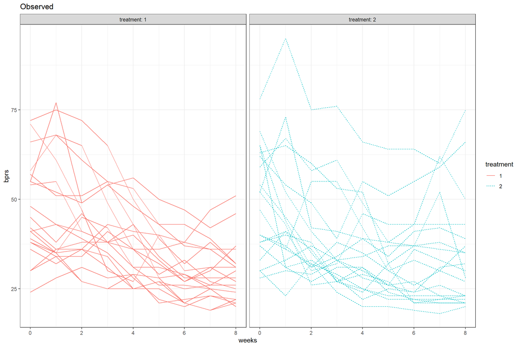

```r
# draw the plot of RATSL
ggplot(BPRSL, aes(x = week, y = bprs, group = id, col = treatment)) +
  geom_line(aes(linetype = treatment)) +
  scale_x_continuous(name = "weeks") +
  scale_y_continuous(name = "bprs") +
  ggtitle("Observed") +
  facet_grid(. ~ treatment, labeller = label_both) +
  theme(legend.position = "top") + theme_bw()
```

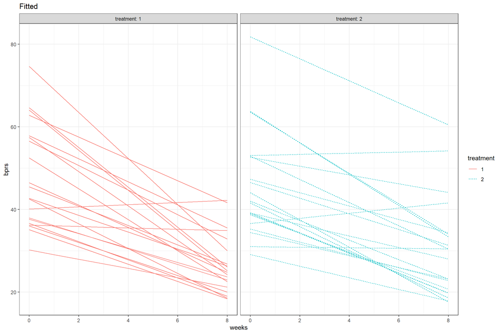

```r
# Create a vector of the fitted values
Fitted <- fitted(BPRS_ref2)

# Create a new column fitted to RATSL

BPRSL <- BPRSL %>%
  mutate(Fitted)

# draw the plot of RATSL
ggplot(BPRSL, aes(x = week, y = Fitted, group = id, col = treatment)) +
  geom_line(aes(linetype = treatment)) +
  scale_x_continuous(name = "weeks") +
  scale_y_continuous(name = "bprs") +
  ggtitle("Fitted") +
  facet_grid(. ~ treatment, labeller = label_both) +
  theme(legend.position = "top") + theme_bw()
```